# Module 01: Foundations, Epistemology, and Working with Social Data in R

Computational Social Science — Graduate & Undergraduate

2026-04-04

# 1 Overview

This module does two things. It lays the intellectual foundations of Computational Social Science — what the field is, what it assumes, where it came from — and it teaches you the R workflow you will use throughout the course. Both halves are equally important. Understanding the foundations without the tools is like understanding carpentry without knowing how to hold a saw. Having the tools without the foundations produces technically correct answers to the wrong questions.

**Learning goals:**

- Explain what CSS is and why it emerged when it did
- Describe the three main epistemological traditions in social science
- Load, inspect, describe, and visualise General Social Survey data in R
- Compute and interpret summary statistics, crosstabulations, and correlations
- Run and read a simple linear regression
- Identify and describe patterns in time-series survey data

# 2 What Is Computational Social Science?

## 2.1 The Problem That Created It

For most of the twentieth century, studying human behaviour at scale was slow and expensive. A nationally representative survey took years from design to publication. Experiments were conducted on undergraduate students from elite universities. Administrative records were largely inaccessible. The data that social scientists had were small, slow, and expensive by today’s standards.

The internet changed this. By the mid-2000s, the digital traces of human behaviour — social media posts, search queries, purchase records, GPS movements, email networks — were accumulating at a scale unimaginable a decade earlier. Companies like Google, Facebook, and Amazon held richer behavioural data about more people than any government statistical agency had ever collected.

In 2009, David Lazer and colleagues published a short manifesto in *Science* coining the term “Computational Social Science” and arguing that these new data sources, combined with computing advances, created conditions for a new kind of social inquiry — one capable of studying human behaviour at societal scale, in real time, with granularity previously impossible.

> **Lazer et al. (2009). Computational social science. *Science*, 323(5915), 721–723.**

Eleven years later, the same group published a sober reassessment: progress had been real, but serious obstacles remained — corporate data locked behind NDAs, replication failures, ethical gaps, and the chronic problem of computer scientists studying social questions without social theory, and social scientists using computational methods without understanding them.

> **Lazer et al. (2020). Computational social science: Obstacles and opportunities. *Science*, 369(6507), 1060–1062.**

Both papers are assigned reading. The contrast between the 2009 ambition and the 2020 sobriety is itself a lesson in how fields mature.

## 2.2 What Makes CSS Distinctive

CSS is not simply social science done on a computer. Econometricians have been running regressions on computers since the 1960s. What makes CSS distinctive is:

**New data types.** CSS works with data that did not previously exist in usable form: the complete text of 500,000 congressional speeches, the social networks of a billion Facebook users, the second-by-second movement of millions of smartphones. Analysing these requires methods — natural language processing, network analysis, spatial statistics — absent from traditional training.

**Scale.** CSS often works at a scale where no individual case can be manually inspected. When you analyse 50 million tweets you cannot read them. This is both a power (patterns invisible at small N become visible) and a liability (you can never verify whether your model captures what you intend).

**New ethical terrain.** Traditional research ethics assumed participants know they are being studied, give informed consent, and exist within bounded, supervised research contexts. CSS often involves studying people who have no idea they are being observed, using data generated for entirely different purposes.

**True interdisciplinarity.** CSS sits between sociology, political science, economics, psychology, communication, geography, and computer science. No single discipline owns it. Reading CSS papers requires knowing which disciplinary standards the authors are working within — because those standards differ markedly across fields.

# 3 Epistemological Foundations

## 3.1 Why This Is Not Optional

Every methodological choice you make — what to measure, what model to fit, how to interpret a result — rests on assumptions about what social reality is and how it can be known. If you are unaware of those assumptions, you cannot evaluate whether your conclusions are warranted.

## 3.2 Positivism

Positivism treats social reality as something that exists independently of our knowledge of it and that can be studied through generalised causal regularities. The goal is explanation and prediction: identify patterns that hold across contexts and use them to explain and forecast social outcomes. Most quantitative social science is positivist.

*CSS context:* When you run a sentiment classifier on a million tweets and report that political discourse became more negative, you are working positivistically — treating sentiment as an objective property of text that can be measured and compared. The question you must ask is whether your classifier actually measures what you mean by negativity, or whether it is measuring something else that correlates with it.

## 3.3 Interpretivism

Interpretivism holds that social life is fundamentally about meaning. People do not just behave — they interpret their situations, act on beliefs, construct social reality through shared symbols and language. To understand social phenomena you cannot just measure them; you have to understand what they mean to the people involved.

*CSS context:* When you build a topic model and get back clusters of words, you cannot label those clusters without interpretive judgment. When you define categories for a text classifier, you are making interpretive choices that shape every downstream result. The interpretive tradition does not disappear from CSS — it is embedded in every modelling decision, visible or not.

## 3.4 Critical Realism

Critical realism, developed by Roy Bhaskar, argues that both positivism and interpretivism miss something. Positivism is right that social structures (class, race, patriarchy) have real effects regardless of what anyone believes about them. Interpretivism is right that these structures are not directly observable — they must be inferred from the effects they produce. Critical realism’s contribution is the concept of *generative mechanisms*: the underlying structures and processes that produce the observable patterns we study. The job of social science, on this view, is to identify mechanisms, not just describe regularities.

*CSS context:* Critical realism is useful for asking what lies behind a CSS pattern. When a network analysis shows political information clustering in ideologically homogeneous communities, a critical realist asks: what generative mechanism produces this? Algorithmic filtering? Selective following? Network dynamics? The pattern is real; understanding what produces it requires theoretical reasoning and often additional methods.

## 3.5 The Three Modes of Reasoning

**Deductive reasoning** starts with theory, derives a hypothesis, tests it. Most hypothesis-testing is deductive. Risk: testing the wrong prediction, or testing it in a way that doesn’t actually challenge the theory.

**Inductive reasoning** starts with data, identifies patterns, builds theory. Risk: the patterns may be statistical artefacts that don’t generalise.

**Abductive reasoning** (C.S. Peirce) moves back and forth between theory and data, driven by surprise — asking at each stage what the most plausible explanation of the current evidence is. This is what good researchers actually do most of the time, and it is the logic formalised in Nelson’s Computational Grounded Theory (Module 2).

# 4 Research Ethics in CSS

## 4.1 The Facebook Emotional Contagion Experiment

In 2014, Facebook researchers published an experiment in which they manipulated the News Feed of 689,003 users to show either more positive or more negative content, then measured whether this changed the emotional content of users’ own subsequent posts. It did. The finding was scientifically interesting. The ethical response was a firestorm.

The experiment violated meaningful informed consent (ToS boilerplate is not consent), deliberately induced negative emotional states in potentially vulnerable people with no support mechanism, and fell through every gap in existing IRB oversight because Facebook is not a federally funded academic institution.

The researchers were not malicious — they appear to have genuinely believed they were operating within acceptable norms. This is the most important lesson: ethical violations in CSS are usually not deliberate. They arise from not thinking carefully enough about the gap between what is technically permitted and what is actually acceptable.

**The four principles, as CSS complicates them:**

- *Informed consent:* Meaningful consent requires knowing specifically what you are agreeing to. Platform ToS is not meaningful consent.
- *Beneficence:* Harms in CSS may be diffuse, delayed, or emerge from data combinations the researcher never anticipated.
- *Privacy:* “Anonymised” data can often be re-identified by combining multiple datasets. Geolocation is almost never truly anonymous.
- *Justice:* CSS systematically over-studies digitally active, younger, urban, English-speaking populations.

> **Core text:** Salganik, M.J. (2018). *Bit by Bit: Social Research in the Digital Age*. Free: https://www.bitbybitbook.com/

# 5 The General Social Survey

## 5.1 What It Is

The General Social Survey (GSS) has been conducted since 1972 by NORC at the University of Chicago, funded by the National Science Foundation. It is a biennial (sometimes annual) nationally representative survey of English- and Spanish-speaking US adults. Its most important feature is *continuity*: hundreds of questions asked in identical wording, year after year, for fifty years. This allows researchers to distinguish genuine social change from changes in question wording or survey methodology.

We use the `gssr` package (Healy), which wraps the full cumulative GSS file. We use the GSS throughout this course for examples across every method.

## 5.2 Loading and First Look

```r
library(gssr)
data(gss_all)

# Always start by understanding what you have
cat("Rows (respondents):", format(nrow(gss_all), big.mark=","), "\n")
```

```
## Rows (respondents): 75,699
```

```r
cat("Columns (variables):", format(ncol(gss_all), big.mark=","), "\n")
```

```
## Columns (variables): 6,942
```

```r
cat("Years covered:", min(gss_all$year), "to", max(gss_all$year), "\n")
```

```
## Years covered: 1972 to 2024
```

With over 6,000 variables, you must know what you are looking for. For this module we select a focused subset covering happiness, social trust, political views, institutional confidence, and basic demographics.

```r
gss <- gss_all |>
  select(
    year, age, sex, race, educ, degree,
    income16,    # 26-point family income scale
    polviews,    # ideology: 1=ext.liberal → 7=ext.conservative
    partyid,     # 0=strong Dem → 6=strong Rep
    happy,       # 1=very happy, 2=pretty happy, 3=not too happy
    trust,       # 1=people can be trusted, 2=can't, 3=depends
    confinan,    # confidence in banks: 1=great deal → 3=hardly any
    conjudge,    # confidence in Supreme Court
    consci,      # confidence in science
    conpress,    # confidence in press
    conarmy      # confidence in military
  ) |>
  mutate(across(everything(), as.numeric))

cat("Working dataset:", nrow(gss), "×", ncol(gss), "\n")
```

```
## Working dataset: 75699 × 16
```

# 6 Part A: Describing a Single Variable

## 6.1 Distribution and Central Tendency

The first step in any analysis is to understand each variable’s distribution on its own before looking at relationships. Use `summary()` for a quick overview and `table()` for categorical variables.

```r
# summary() gives: min, Q1, median, mean, Q3, max, and count of NAs
# This is the first thing to run on any variable
summary(gss$happy)
```

```
##    Min. 1st Qu.  Median    Mean 3rd Qu.    Max.    NA's
##   1.000   1.000   2.000   1.845   2.000   3.000    4830
```

**Reading `summary()` output:** The median and mean should be close for symmetric distributions. A large gap between them signals skewness. The NA count tells you how many respondents did not answer — always note this before any analysis.

For a categorical variable like `happy` (coded 1, 2, 3), a frequency table is more informative than a mean:

```r
# table() counts each value; prop.table() converts to proportions
happy_tab <- table(gss$happy, useNA="ifany")
round(prop.table(happy_tab) * 100, 1)
```

```
##
##    1    2    3 <NA>
## 27.8 52.5 13.3  6.4
```

We can make this more readable with labels:

```r
gss |>
  filter(!is.na(happy)) |>
  mutate(happy_f = factor(happy, 1:3,
    c("Very happy", "Pretty happy", "Not too happy"))) |>
  count(happy_f) |>
  mutate(pct = round(n / sum(n) * 100, 1)) |>
  kbl(col.names = c("Happiness", "N", "%"),
      caption   = "Distribution of Self-Reported Happiness, GSS All Years") |>
  kable_styling(bootstrap_options = c("striped","hover"), full_width = FALSE)
```

Distribution of Self-Reported Happiness, GSS All Years

| Happiness | N | % |
| --- | --- | --- |
| Very happy | 21069 | 29.7 |
| Pretty happy | 39705 | 56.0 |
| Not too happy | 10095 | 14.2 |

## 6.2 Visualising a Distribution

Always plot the distribution of a continuous variable before doing anything else with it. A histogram shows the shape; a density curve smooths it.

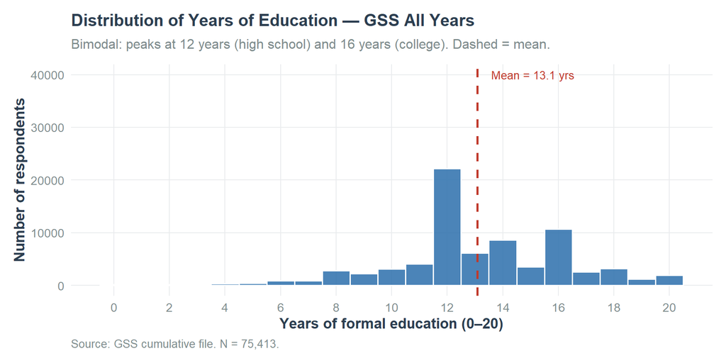

```r
gss |>
  filter(!is.na(educ), educ >= 0) |>
  ggplot(aes(x = educ)) +
  geom_histogram(binwidth = 1, fill = "#2C6FAC", colour = "white", alpha = 0.85) +
  geom_vline(aes(xintercept = mean(educ, na.rm=TRUE)),
             colour = "#C0392B", linewidth = 1, linetype = "dashed") +
  annotate("text", x = mean(gss$educ, na.rm=TRUE) + 0.5, y = 40000,
           label = paste0("Mean = ", round(mean(gss$educ, na.rm=TRUE), 1), " yrs"),
           hjust = 0, colour = "#C0392B", size = 3.5) +
  scale_x_continuous(breaks = seq(0, 20, 2)) +
  labs(
    title    = "Distribution of Years of Education — GSS All Years",
    subtitle = "Bimodal: peaks at 12 years (high school) and 16 years (college). Dashed = mean.",
    x = "Years of formal education (0–20)",
    y = "Number of respondents",
    caption  = paste0("Source: GSS cumulative file. N = ",
                      format(sum(!is.na(gss$educ)), big.mark=","), ".")
  )
```

## 6.3 Summary Statistics Table

For a complete descriptive overview of multiple continuous variables, `skim()` from `skimr` gives far more than `summary()`:

```r
gss |>
  select(age, educ, income16, polviews) |>
  filter(if_all(everything(), ~!is.na(.x))) |>
  skim() |>
  select(skim_variable, n_missing, numeric.mean, numeric.sd,
         numeric.p0, numeric.p25, numeric.p50, numeric.p75, numeric.p100) |>
  mutate(across(where(is.numeric), ~round(.x, 2))) |>
  kbl(col.names = c("Variable", "N missing", "Mean", "SD",
                    "Min", "Q1", "Median", "Q3", "Max"),
      caption   = "Descriptive Statistics — Continuous Variables, GSS") |>
  kable_styling(bootstrap_options = c("striped","hover","condensed"))
```

Descriptive Statistics — Continuous Variables, GSS

| Variable | N missing | Mean | SD | Min | Q1 | Median | Q3 | Max |
| --- | --- | --- | --- | --- | --- | --- | --- | --- |
| age | 0 | 50.16 | 17.46 | 18 | 35 | 50 | 64 | 89 |
| educ | 0 | 14.29 | 2.87 | 0 | 12 | 14 | 16 | 20 |
| income16 | 0 | 18.19 | 5.91 | 1 | 15 | 19 | 22 | 26 |
| polviews | 0 | 4.00 | 1.52 | 1 | 3 | 4 | 5 | 7 |

**Reading this table:** The SD (standard deviation) tells you how spread out values are — a rule of thumb is that ~68% of observations fall within ±1 SD of the mean. Compare `educ` (SD ≈ 3) to `income16` (SD ≈ 6) to understand relative variability. The quartiles (Q1, Q3) are resistant to outliers and give you the range of the middle 50% of cases.

# 7 Part B: Relationships Between Two Variables

## 7.1 Categorical × Categorical: Crosstabulation

When both variables are categorical, a crosstabulation (contingency table) shows how their distributions relate. We add row percentages to see the conditional distribution of one variable given the other.

```r
# Does educational attainment predict social trust?
cross_df <- gss |>
  filter(!is.na(trust), !is.na(degree)) |>
  mutate(
    trust_f  = factor(trust, 1:3, c("Can trust","Cannot","Depends")),
    degree_f = factor(degree, 0:4,
      c("< HS","HS","Some college","Bachelor's","Graduate"))
  ) |>
  count(degree_f, trust_f) |>
  group_by(degree_f) |>
  mutate(row_pct = round(n / sum(n) * 100, 1)) |>
  ungroup()

# Pivot to wide for display
cross_df |>
  select(degree_f, trust_f, row_pct) |>
  pivot_wider(names_from = trust_f, values_from = row_pct) |>
  kbl(col.names = c("Highest Degree", "Can trust (%)",
                    "Cannot trust (%)", "Depends (%)"),
      caption   = "Social Trust by Educational Attainment (row percentages), GSS") |>
  kable_styling(bootstrap_options = c("striped","hover")) |>
  footnote(general = paste(
    "Row percentages sum to 100 within each education category.",
    "Read across: among those with Graduate degrees, X% say most people can be trusted."))
```

Social Trust by Educational Attainment (row percentages), GSS

| Highest Degree | Can trust (%) | Cannot trust (%) | Depends (%) |
| --- | --- | --- | --- |
| < HS | 23.0 | 73.0 | 3.9 |
| HS | 34.4 | 61.3 | 4.3 |
| Some college | 35.5 | 58.8 | 5.7 |
| Bachelor’s | 52.6 | 41.1 | 6.3 |
| Graduate | 60.5 | 31.5 | 8.0 |

**How to read a crosstab:** Read *across* each row, not down columns. Each row shows the distribution of trust *within* that education category. Look for rows that differ substantially — if every row looks the same, education and trust are unrelated. If the “Can trust” percentage increases consistently as you move from < HS to Graduate, there is a positive association.

A chi-squared test tells us whether the association is statistically significant:

```r
# Build the contingency table for the test
ct <- gss |>
  filter(!is.na(trust), !is.na(degree)) |>
  mutate(trust = factor(trust), degree = factor(degree)) |>
  with(table(degree, trust))

chisq_result <- chisq.test(ct)

cat("Chi-squared test of independence: Trust × Education\n\n")
```

```
## Chi-squared test of independence: Trust × Education
```

```r
cat("Chi-squared statistic:", round(chisq_result$statistic, 2), "\n")
```

```
## Chi-squared statistic: 2628.14
```

```r
cat("Degrees of freedom:   ", chisq_result$parameter, "\n")
```

```
## Degrees of freedom:    8
```

```r
cat("p-value:              ", format(chisq_result$p.value, scientific=TRUE), "\n\n")
```

```
## p-value:               0e+00
```

```r
cat("Interpretation: A significant chi-squared (p < .05) means the two variables are\n")
```

```
## Interpretation: A significant chi-squared (p < .05) means the two variables are
```

```r
cat("NOT independent in the population — knowing someone's education level tells us\n")
```

```
## NOT independent in the population — knowing someone's education level tells us
```

```r
cat("something about their trust. It does NOT tell us the size or direction of the\n")
```

```
## something about their trust. It does NOT tell us the size or direction of the
```

```r
cat("relationship, or whether it is causal.\n")
```

```
## relationship, or whether it is causal.
```

## 7.2 Continuous × Continuous: Correlation

When both variables are continuous (or at least ordinal with enough levels), we use correlation. The Pearson correlation *r* ranges from -1 (perfect negative) to 0 (no linear relationship) to +1 (perfect positive).

```r
# Correlation between education and political views
# First, always inspect both distributions and the scatterplot

# Calculate correlation and its confidence interval
cor_result <- cor.test(
  gss$educ[!is.na(gss$educ) & !is.na(gss$polviews)],
  gss$polviews[!is.na(gss$educ) & !is.na(gss$polviews)],
  method = "pearson"
)

cat("=== Pearson Correlation: Education × Political Views ===\n\n")
```

```
## === Pearson Correlation: Education × Political Views ===
```

```r
cat("r =", round(cor_result$estimate, 4), "\n")
```

```
## r = -0.07
```

```r
cat("95% CI: [", round(cor_result$conf.int[1], 3),
    ",", round(cor_result$conf.int[2], 3), "]\n")
```

```
## 95% CI: [ -0.078 , -0.062 ]
```

```r
cat("t =", round(cor_result$statistic, 3),
    "| df =", cor_result$parameter,
    "| p =", format(cor_result$p.value, scientific=TRUE), "\n\n")
```

```
## t = -17.978 | df = 65697 | p = 4.353038e-72
```

```r
cat("Interpreting r:", round(cor_result$estimate, 3), "\n")
```

```
## Interpreting r: -0.07
```

```r
cat("  Sign: negative → higher education associated with MORE liberal views\n")
```

```
##   Sign: negative → higher education associated with MORE liberal views
```

```r
cat("  Magnitude: |r| < .10 = trivial, .10-.30 = small, .30-.50 = moderate, > .50 = large\n")
```

```
##   Magnitude: |r| < .10 = trivial, .10-.30 = small, .30-.50 = moderate, > .50 = large
```

```r
cat("  R-squared:", round(cor_result$estimate^2 * 100, 1),
    "% of variance in polviews shared with educ\n")
```

```
##   R-squared: 0.5 % of variance in polviews shared with educ
```

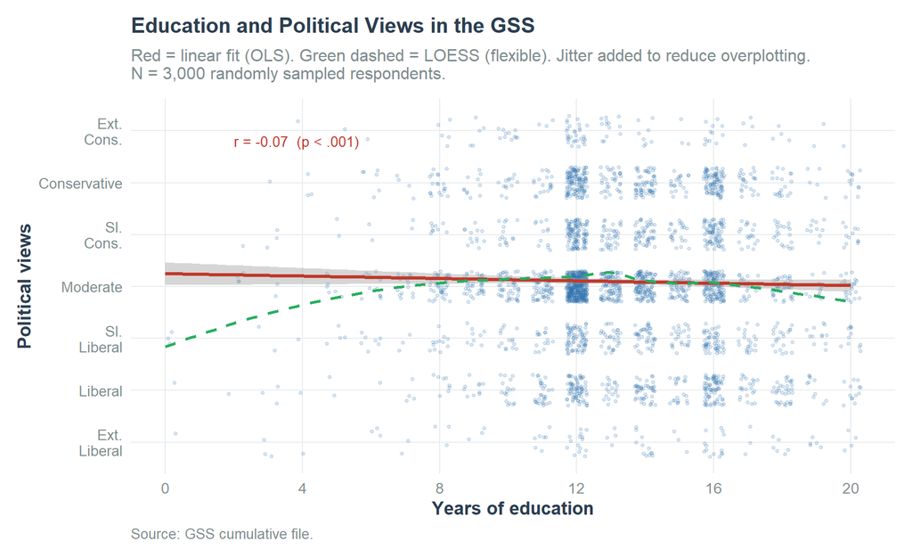

```r
# Always visualise the relationship — correlation summarises it but a plot shows its shape
set.seed(42)
gss |>
  filter(!is.na(educ), !is.na(polviews)) |>
  slice_sample(n = 3000) |>        # sample for plotting speed
  ggplot(aes(x = educ, y = polviews)) +
  geom_jitter(alpha = 0.15, size = 0.8, colour = "#2C6FAC",
              width = 0.3, height = 0.3) +
  geom_smooth(method = "lm", colour = "#C0392B",
              linewidth = 1.2, se = TRUE) +
  geom_smooth(method = "loess", colour = "#27AE60",
              linewidth = 1, se = FALSE, linetype = "dashed") +
  scale_x_continuous(breaks = seq(0, 20, 4), name = "Years of education") +
  scale_y_continuous(breaks = 1:7,
    labels = c("Ext.\nLiberal","Liberal","Sl.\nLiberal","Moderate",
               "Sl.\nCons.","Conservative","Ext.\nCons."),
    name = "Political views") +
  annotate("text", x = 2, y = 6.8, hjust = 0, size = 3.5, colour = "#C0392B",
           label = paste0("r = ", round(cor_result$estimate, 3),
                          "  (p < .001)")) +
  labs(
    title    = "Education and Political Views in the GSS",
    subtitle = paste("Red = linear fit (OLS). Green dashed = LOESS (flexible).",
                     "Jitter added to reduce overplotting.",
                     "\nN = 3,000 randomly sampled respondents."),
    caption  = "Source: GSS cumulative file."
  )
```

**Reading this scatterplot:** Each point is one respondent. The OLS line (red) shows the linear trend: the negative slope confirms the negative correlation — more education is weakly associated with more liberal views. The LOESS curve (green dashed) shows whether the relationship is *actually* linear: if the LOESS follows the OLS line closely, the linear assumption is reasonable. If the LOESS curves substantially away from the OLS, the relationship is nonlinear.

## 7.3 Computing a Full Correlation Matrix

When you have multiple continuous variables, compute all pairwise correlations at once:

```r
cor_vars <- gss |>
  select(age, educ, income16, polviews, partyid) |>
  filter(if_all(everything(), ~!is.na(.x)))

cor_mat <- cor(cor_vars, use = "complete.obs") |> round(3)

cor_mat |>
  kbl(caption = "Pairwise Pearson Correlations — Continuous GSS Variables") |>
  kable_styling(bootstrap_options = c("striped","hover","condensed")) |>
  # Colour the cells by strength of correlation
  column_spec(2:6, color = "white",
    background = ifelse(abs(cor_mat) > 0.4, "#2C6FAC",
                 ifelse(abs(cor_mat) > 0.2, "#7FB3D3", "white"))) |>
  footnote(general = paste(
    "Diagonal = 1.0 (each variable correlates perfectly with itself).",
    "Off-diagonal = correlation between two variables.",
    "\nBlue = |r| > .20. Darker blue = |r| > .40. White = |r| < .20."
  ))
```

Pairwise Pearson Correlations — Continuous GSS Variables

|  | age | educ | income16 | polviews | partyid |
| --- | --- | --- | --- | --- | --- |
| age | 1.000 | 0.018 | 0.033 | 0.129 | 0.014 |
| educ | 0.018 | 1.000 | 0.399 | -0.130 | -0.073 |
| income16 | 0.033 | 0.399 | 1.000 | 0.002 | 0.050 |
| polviews | 0.129 | -0.130 | 0.002 | 1.000 | 0.566 |
| partyid | 0.014 | -0.073 | 0.050 | 0.566 | 1.000 |

Note:  
Diagonal = 1.0 (each variable correlates perfectly with itself). Off-diagonal = correlation between two variables. Blue = |r| > .20. Darker blue = |r| > .40. White = |r| < .20.

# 8 Part C: Simple Regression — Predicting One Variable from Another

## 8.1 What Regression Does and Why

Correlation tells you the *strength and direction* of a linear relationship. Regression tells you the *equation* of that relationship — exactly how much Y changes for each one-unit change in X, on average. Regression also generalises naturally to multiple predictors and to controlling for confounders.

The simple linear regression model is:
$$Y_i = \beta_0 + \beta_1 X_i +
\varepsilon_i$$

- $\beta_0$ (the **intercept**): the predicted value of Y when X = 0
- $\beta_1$ (the **slope**): the change in the *predicted* value of Y for a one-unit increase in X
- $\varepsilon_i$ (the **residual**): the difference between the observed and predicted Y for case *i*

The OLS criterion finds the values of $\beta_0$ and $\beta_1$ that minimise $\sum \varepsilon_i^2$ — the sum of squared residuals.

## 8.2 Running and Reading a Regression

```r
# Predict happiness (higher = less happy, remember!) from education
# Restrict to 2010-2022 for a more current picture
gss_reg <- gss |>
  filter(year >= 2010, !is.na(happy), !is.na(educ),
         !is.na(age), !is.na(sex), !is.na(income16))

m1 <- lm(happy ~ educ, data = gss_reg)

# Always start with summary() — it gives everything you need
summary(m1)
```

```
##
## Call:
## lm(formula = happy ~ educ, data = gss_reg)
##
## Residuals:
##      Min       1Q   Median       3Q      Max
## -1.20211 -0.04934  0.03552  0.10342  1.13737
##
## Coefficients:
##              Estimate Std. Error t value Pr(>|t|)
## (Intercept)  2.202105   0.027986  78.686   <2e-16 ***
## educ        -0.016974   0.001925  -8.817   <2e-16 ***
## ---
## Signif. codes:  0 '***' 0.001 '**' 0.01 '*' 0.05 '.' 0.1 ' ' 1
##
## Residual standard error: 0.654 on 13843 degrees of freedom
## Multiple R-squared:  0.005584,   Adjusted R-squared:  0.005512
## F-statistic: 77.74 on 1 and 13843 DF,  p-value: < 2.2e-16
```

**Reading the `lm()` summary output — every piece matters:**

Reading the lm() Summary Output — Line by Line

| Output section | What it means |
| --- | --- |
| Call | The formula you called — confirms you are fitting the right model |
| Residuals | Five-number summary of residuals (observed minus predicted Y). Median ≈ 0 suggests reasonable fit. |
| Coefficients: (Intercept) | Predicted happy when educ = 0 (no formal education). Rarely interpretable on its own. |
| Coefficients: educ | The slope: for each 1 additional year of education, predicted happy changes by this amount |
| Std. Error | The uncertainty in each coefficient estimate. Smaller = more precise. |
| t value | Coefficient ÷ Std.Error. Larger \|t\| = less consistent with H0: coefficient = 0 |
| Pr(>\|t\|) | Probability of observing \|t\| this large if H0 is true. Stars indicate thresholds. |
| Residual SE | Average size of residuals (in the same units as Y). Measure of model accuracy. |
| Multiple R-squared | Proportion of Y variance explained by the model. 0 = explains nothing, 1 = perfect. |
| Adjusted R-squared | R² penalised for number of predictors. Use this when comparing models. |
| F-statistic | Tests whether the full model explains significantly more than an intercept-only model. |

**Interpretation of this specific model:**

- The intercept (≈ 2.20) is the predicted happiness score for someone with zero years of education. Since the scale runs 1 (very happy) to 3 (not happy), this means someone with no education is predicted to fall between “pretty happy” and “not happy” on average.
- The education slope (likely small and negative) means each additional year of education is associated with a small *decrease* in the happiness score — i.e., slightly *more* happiness, because lower scores = more happy. A slope of −0.02 means 10 more years of education predicts a score 0.2 points lower (happier).
- R² is likely very small (< 0.02) — education alone explains almost none of the variation in happiness. This is normal for social outcomes predicted by a single variable.

## 8.3 Multiple Regression: Adding Controls

```r
# Add age, sex, and income as controls
# This asks: what is the education-happiness association
# AFTER accounting for age, sex, and income?
m2 <- lm(happy ~ educ + age + I(sex == 2) + income16, data = gss_reg)

# Extract and display coefficients cleanly
broom::tidy(m2, conf.int = TRUE) |>
  mutate(across(c(estimate, std.error, conf.low, conf.high), ~round(.x, 4)),
         p.value = round(p.value, 4),
         term    = recode(term,
           "(Intercept)"   = "Intercept",
           "educ"          = "Education (years)",
           "age"           = "Age (years)",
           "I(sex == 2)TRUE" = "Female (vs. male)",
           "income16"      = "Family income (26-pt scale)"
         ),
         stars   = case_when(
           p.value < .001 ~ "***",
           p.value < .01  ~ "**",
           p.value < .05  ~ "*",
           p.value < .10  ~ ".",
           TRUE           ~ ""
         )) |>
  kbl(col.names = c("Predictor","Estimate","SE","t","p","CI low","CI high",""),
      caption   = "Multiple Regression: Predictors of Happiness (GSS 2010–2022)") |>
  kable_styling(bootstrap_options = c("striped","hover")) |>
  footnote(general = paste(
    "DV: happy (1=very happy, 2=pretty happy, 3=not too happy). Lower score = happier.",
    "\nNegative coefficient = predictor associated with MORE happiness.",
    "*** p<.001, ** p<.01, * p<.05, . p<.10"
  ))
```

Multiple Regression: Predictors of Happiness (GSS 2010–2022)

| Predictor | Estimate | SE | t | p | CI low | CI high |  |
| --- | --- | --- | --- | --- | --- | --- | --- |
| Intercept | 2.3803 | 0.0327 | 72.7700192 | 0.0000 | 2.3161 | 2.4444 | *** |
| Education (years) | 0.0016 | 0.0021 | 0.7879296 | 0.4308 | -0.0024 | 0.0057 |  |
| Age (years) | -0.0006 | 0.0003 | -1.8910055 | 0.0586 | -0.0012 | 0.0000 | . |
| Female (vs. male) | -0.0174 | 0.0110 | -1.5802991 | 0.1141 | -0.0391 | 0.0042 |  |
| Family income (26-pt scale) | -0.0223 | 0.0010 | -22.1847619 | 0.0000 | -0.0243 | -0.0204 | *** |

Note:  
DV: happy (1=very happy, 2=pretty happy, 3=not too happy). Lower score = happier. Negative coefficient = predictor associated with MORE happiness. *** p<.001, ** p<.01, * p<.05, . p<.10

**Interpreting multiple regression coefficients:**

Each coefficient represents the relationship between that predictor and Y *holding all other predictors constant*. This is the crucial advantage of multiple regression over pairwise correlations: it lets you ask “what is the relationship between education and happiness among people of the same age, sex, and income level?”

- If the education coefficient changes substantially between `m1` (simple) and `m2` (with controls), those controls are confounders — they were partly explaining the education-happiness association.
- If it stays similar, education has an association with happiness that is not simply due to being older, female, or having higher income.

Model comparison:

```r
# Compare simple to multiple regression
cat("=== Model Comparison ===\n\n")
```

```
## === Model Comparison ===
```

```r
cat("Simple regression (educ only):      R² =",
    round(summary(m1)$r.squared, 4), "\n")
```

```
## Simple regression (educ only):      R² = 0.0056
```

```r
cat("Multiple regression (educ + controls): R² =",
    round(summary(m2)$r.squared, 4), "\n\n")
```

```
## Multiple regression (educ + controls): R² = 0.0402
```

```r
cat("Adding age, sex, income adds",
    round((summary(m2)$r.squared - summary(m1)$r.squared)*100, 2),
    "percentage points of explained variance.\n\n")
```

```
## Adding age, sex, income adds 3.46 percentage points of explained variance.
```

```r
# F-test for model improvement
anova_result <- anova(m1, m2)
cat("F-test for improvement from m1 to m2:\n")
```

```
## F-test for improvement from m1 to m2:
```

```r
cat("  F =", round(anova_result$F[2], 2),
    "| p =", format(anova_result$`Pr(>F)`[2], scientific=TRUE), "\n")
```

```
##   F = 166.31 | p = 6.413296e-106
```

```r
cat("  A significant F means m2 explains significantly more variance than m1.\n")
```

```
##   A significant F means m2 explains significantly more variance than m1.
```

# 9 Part D: Visualising Change Over Time

## 9.1 Plotting Time-Series Data

The GSS’s continuity makes it uniquely suited to studying social change. A time-series plot is the right visualisation for tracking how a quantity changes over years.

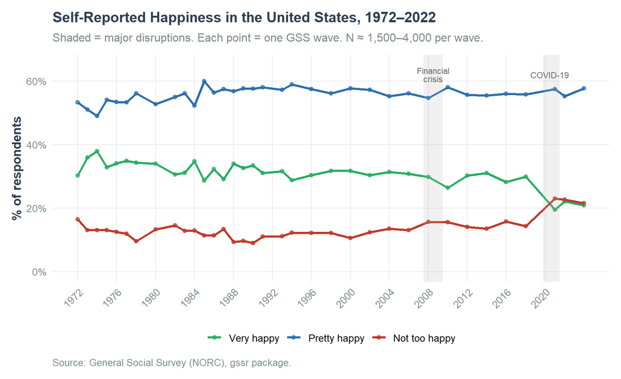

```r
happy_ts <- gss |>
  filter(!is.na(happy)) |>
  mutate(happy_f = factor(happy, 1:3, c("Very happy","Pretty happy","Not too happy"))) |>
  count(year, happy_f) |>
  group_by(year) |>
  mutate(pct = n / sum(n) * 100, total = sum(n)) |>
  ungroup() |>
  # Only plot years with at least 500 respondents
  filter(total >= 500)

ggplot(happy_ts, aes(x = year, y = pct, colour = happy_f)) +
  geom_line(linewidth = 1.1) +
  geom_point(size = 1.8, alpha = 0.7) +
  annotate("rect", xmin=2007.5, xmax=2009.5, ymin=-Inf, ymax=Inf,
           fill="grey70", alpha=0.2) +
  annotate("text", x=2008.5, y=62, label="Financial\ncrisis",
           size=3, colour="grey40", hjust=0.5, lineheight=0.85) +
  annotate("rect", xmin=2019.8, xmax=2021.5, ymin=-Inf, ymax=Inf,
           fill="grey70", alpha=0.2) +
  annotate("text", x=2020.5, y=62, label="COVID-19",
           size=3, colour="grey40", hjust=0.5) +
  scale_colour_manual(values=c("Very happy"="#27AE60",
    "Pretty happy"="#2C6FAC","Not too happy"="#C0392B"), name=NULL) +
  scale_x_continuous(breaks=seq(1972,2022,by=4)) +
  scale_y_continuous(limits=c(0,65), labels=\(x) paste0(x,"%")) +
  labs(
    title    = "Self-Reported Happiness in the United States, 1972–2022",
    subtitle = paste("Shaded = major disruptions. Each point = one GSS wave.",
                     "N ≈ 1,500–4,000 per wave."),
    x=NULL, y="% of respondents",
    caption  = "Source: General Social Survey (NORC), gssr package."
  ) +
  theme(axis.text.x=element_text(angle=45,hjust=1), legend.position="bottom")
```

**Interpreting time-series patterns:**

Look for: (1) *long-run trends* — a consistent upward or downward drift over decades; (2) *step changes* — sudden jumps following identifiable events; (3) *cyclical patterns* — regular rises and falls tied to economic cycles or electoral cycles; (4) *stability* — little change despite historical turbulence.

## 9.2 Comparing Groups Over Time

When you want to see whether a trend differs across demographic groups, use `facet_wrap()` or colour by group within a single panel:

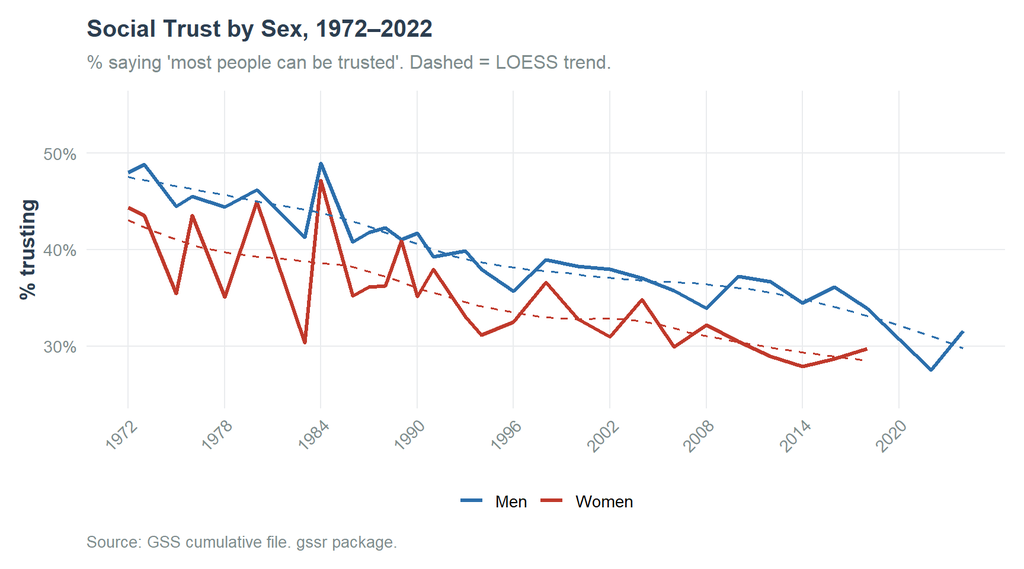

```r
trust_sex <- gss |>
  filter(!is.na(trust), !is.na(sex)) |>
  mutate(
    trusts = as.integer(trust == 1),
    sex_f  = factor(sex, 1:2, c("Men","Women"))
  ) |>
  group_by(year, sex_f) |>
  summarise(pct_trust = mean(trusts, na.rm=TRUE)*100,
            n = sum(!is.na(trusts)), .groups="drop") |>
  filter(n >= 100)

ggplot(trust_sex, aes(x=year, y=pct_trust, colour=sex_f)) +
  geom_line(linewidth=1.2) +
  geom_smooth(method="loess", span=0.6, se=FALSE,
              linewidth=0.7, linetype="dashed") +
  scale_colour_manual(values=c(Men="#2C6FAC", Women="#C0392B"), name=NULL) +
  scale_y_continuous(labels=\(x) paste0(x,"%"), limits=c(25,55)) +
  scale_x_continuous(breaks=seq(1972,2022,by=6)) +
  labs(
    title    = "Social Trust by Sex, 1972–2022",
    subtitle = "% saying 'most people can be trusted'. Dashed = LOESS trend.",
    x=NULL, y="% trusting",
    caption  = "Source: GSS cumulative file. gssr package."
  ) +
  theme(legend.position="bottom",
        axis.text.x=element_text(angle=45,hjust=1))
```

**What group comparisons add:** A single trend line (all respondents together) shows the aggregate. Splitting by group shows whether the trend is universal or concentrated in specific populations. If men’s trust has fallen sharply but women’s has not, the aggregate decline masks a gendered process. This is the first step toward understanding *who* drives aggregate social change.

# 10 Part E: Checking Your Data Before Analysis

## 10.1 Missing Data Patterns

Before any multivariate analysis, examine which variables have missing data and whether it is likely systematic:

```r
gss |>
  filter(year >= 2010) |>
  summarise(across(everything(), ~round(mean(is.na(.x))*100, 1))) |>
  pivot_longer(everything(), names_to="Variable", values_to="Pct_Missing") |>
  arrange(desc(Pct_Missing)) |>
  filter(Pct_Missing > 0) |>
  mutate(Flag = ifelse(Pct_Missing > 20, "⚠ High", "")) |>
  head(12) |>
  kbl(col.names=c("Variable","% Missing",""),
      caption="Variable Missingness (GSS 2010–2022, top 12)") |>
  kable_styling(bootstrap_options=c("striped","hover","condensed"), full_width=FALSE) |>
  footnote(general=paste(
    "⚠ = more than 20% missing. High missingness may indicate:",
    "(1) the question was not asked every year,",
    "(2) the question is sensitive (non-response bias),",
    "(3) a filter question applies (only asked of a subsub-sample)."
  ))
```

Variable Missingness (GSS 2010–2022, top 12)

| Variable | % Missing |  |
| --- | --- | --- |
| trust | 55.7 | ⚠ High |
| income16 | 36.9 | ⚠ High |
| consci | 35.2 | ⚠ High |
| conjudge | 34.5 | ⚠ High |
| conpress | 34.0 | ⚠ High |
| conarmy | 33.9 | ⚠ High |
| confinan | 33.6 | ⚠ High |
| polviews | 3.6 |  |
| age | 3.0 |  |
| partyid | 1.0 |  |
| race | 0.8 |  |
| sex | 0.6 |  |

Note:  
⚠ = more than 20% missing. High missingness may indicate: (1) the question was not asked every year, (2) the question is sensitive (non-response bias), (3) a filter question applies (only asked of a subsub-sample).

**What to do with missing data:**

- First, ask *why* data is missing. Is it a ballot structure issue (not asked of all respondents)? A sensitive item (deliberate non-response)? A filter question (only asked if a prior condition was met)?
- Never simply delete missing cases without considering whether the remaining cases are representative.
- For this course, we use complete-case analysis (dropping rows with missing values on the variables being analysed) and note the resulting N.

## 10.2 Checking Scale Directions

The GSS confidence items are reverse-coded relative to what you might expect: 1 = “a great deal” (high confidence), 3 = “hardly any” (low confidence). Always check:

```r
cat("=== Coding Direction Check ===\n\n")
```

```
## === Coding Direction Check ===
```

```r
cat("confinan (confidence in banks) unique values:\n")
```

```
## confinan (confidence in banks) unique values:
```

```r
print(sort(unique(gss$confinan[!is.na(gss$confinan)])))
```

```
## [1] 1 2 3
```

```r
cat("\nMeaning: 1 = 'a great deal', 2 = 'only some', 3 = 'hardly any'\n")
```

```
##
## Meaning: 1 = 'a great deal', 2 = 'only some', 3 = 'hardly any'
```

```r
cat("LOWER = MORE confidence (counterintuitive!)\n\n")
```

```
## LOWER = MORE confidence (counterintuitive!)
```

```r
cat("happy (general happiness) unique values:\n")
```

```
## happy (general happiness) unique values:
```

```r
print(sort(unique(gss$happy[!is.na(gss$happy)])))
```

```
## [1] 1 2 3
```

```r
cat("\nMeaning: 1 = 'very happy', 2 = 'pretty happy', 3 = 'not too happy'\n")
```

```
##
## Meaning: 1 = 'very happy', 2 = 'pretty happy', 3 = 'not too happy'
```

```r
cat("LOWER = HAPPIER (counterintuitive!)\n\n")
```

```
## LOWER = HAPPIER (counterintuitive!)
```

```r
cat("polviews (political ideology) unique values:\n")
```

```
## polviews (political ideology) unique values:
```

```r
print(sort(unique(gss$polviews[!is.na(gss$polviews)])))
```

```
## [1] 1 2 3 4 5 6 7
```

```r
cat("\nMeaning: 1 = 'extremely liberal', 4 = moderate, 7 = 'extremely conservative'\n")
```

```
##
## Meaning: 1 = 'extremely liberal', 4 = moderate, 7 = 'extremely conservative'
```

```r
cat("HIGHER = MORE conservative (this one follows the usual direction)\n")
```

```
## HIGHER = MORE conservative (this one follows the usual direction)
```

# 11 Part F: A Complete Worked Example

Bringing everything together: a complete, documented analysis pipeline from data loading to reported finding.

**Research question:** Has the relationship between education and social trust changed over time in the United States?

```r
# Step 1: Prepare the data
analysis_df <- gss |>
  filter(!is.na(trust), !is.na(educ), !is.na(year)) |>
  mutate(
    trusts  = as.integer(trust == 1),    # 1 = "can be trusted"
    era     = cut(year,
                  breaks = c(1971, 1984, 1994, 2004, 2014, 2023),
                  labels = c("1972–84","1985–94","1995–04","2005–14","2015–22")),
    educ_grp = cut(educ,
                   breaks = c(-1, 11, 12, 15, 16, 20),
                   labels = c("< HS","HS diploma","Some college",
                              "Bachelor's","Postgrad"))
  )

cat("Step 1 complete. N =", nrow(analysis_df), "\n")
```

```
## Step 1 complete. N = 43299
```

```r
# Step 2: Describe
cat("\nStep 2: Trust rate by education group (all years combined):\n")
```

```
##
## Step 2: Trust rate by education group (all years combined):
```

```r
analysis_df |>
  group_by(educ_grp) |>
  summarise(pct_trust=round(mean(trusts)*100,1), n=n(), .groups="drop") |>
  print()
```

```
## # A tibble: 5 × 3
##   educ_grp     pct_trust     n
##   <fct>            <dbl> <int>
## 1 < HS              22.8  9621
## 2 HS diploma        33.4 13232
## 3 Some college      36.9 10272
## 4 Bachelor's        51.1  5675
## 5 Postgrad          57.5  4499
```

```r
# Step 3: Test the basic association (chi-squared)
ct2 <- table(factor(analysis_df$educ_grp), factor(analysis_df$trusts))
cs  <- chisq.test(ct2)
cat("\nStep 3: Chi-squared test: X² =", round(cs$statistic,1),
    "df =", cs$parameter, "p =", format(cs$p.value, scientific=TRUE), "\n")
```

```
##
## Step 3: Chi-squared test: X² = 2210.4 df = 4 p = 0e+00
```

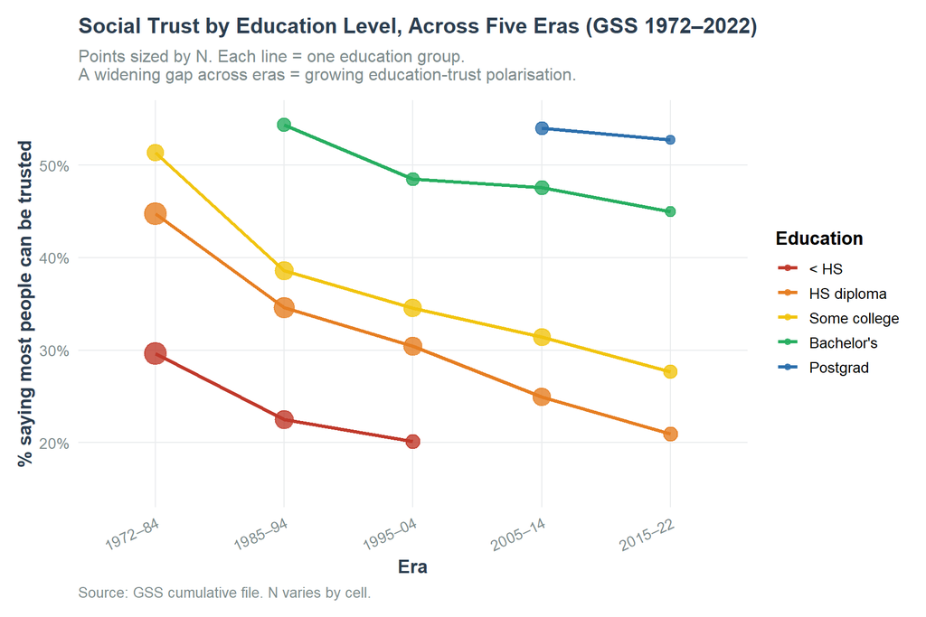

```r
# Step 4: Visualise the interaction (education × era)
trust_era <- analysis_df |>
  filter(!is.na(era), !is.na(educ_grp)) |>
  group_by(era, educ_grp) |>
  summarise(pct_trust=mean(trusts)*100, n=n(), .groups="drop") |>
  filter(n >= 50)

ggplot(trust_era, aes(x=era, y=pct_trust, colour=educ_grp, group=educ_grp)) +
  geom_line(linewidth=1.1) +
  geom_point(aes(size=n), alpha=0.8) +
  scale_colour_manual(values=c("< HS"="#C0392B","HS diploma"="#E67E22",
    "Some college"="#F1C40F","Bachelor's"="#27AE60","Postgrad"="#2C6FAC"),
    name="Education") +
  scale_size_continuous(range=c(2,7), guide="none") +
  scale_y_continuous(labels=\(x) paste0(x,"%"), limits=c(15,55)) +
  labs(
    title    = "Social Trust by Education Level, Across Five Eras (GSS 1972–2022)",
    subtitle = paste("Points sized by N. Each line = one education group.",
                     "\nA widening gap across eras = growing education-trust polarisation."),
    x="Era", y="% saying most people can be trusted",
    caption  = "Source: GSS cumulative file. N varies by cell."
  ) +
  theme(legend.position="right",
        axis.text.x=element_text(angle=25,hjust=1))
```

**Reporting this finding:** The plot answers the research question directly. If the lines diverge over time — the higher-education lines increasing while lower-education lines decrease — this is evidence of a growing education-trust gap. If all lines decline in parallel, the decline in trust is universal across education groups. If lines converge, differences are shrinking.

# 12 Common Beginner Mistakes

[output not shown]

# 13 Check Your Understanding

**1.** Run `summary()` on `gss$polviews`. What does the median tell you about whether Americans lean liberal or conservative on average? What does the mean vs. median comparison tell you about the distribution’s shape?

**2.** Use `table()` to compute the joint distribution of `trust` and `partyid` (recoded to: Democrat ≤ 2, Independent = 3, Republican ≥ 4). Convert to row percentages. What do you observe about how trust relates to partisan identity?

**3.** Run a simple regression of `happy` on `polviews`. Interpret the intercept and slope in substantive terms. Is the relationship statistically significant? Is it practically meaningful?

**4.** Produce a time-series plot of the percentage of Americans reporting “a great deal” of confidence in science (`consci == 1`) from 1973 to 2022. Describe the trend. Do you see any notable changes around identifiable historical events?

# 14 Key Readings

| Citation | Access |
| --- | --- |
| Lazer et al. (2009). CSS. *Science* 323. | Open via PMC |
| Lazer et al. (2020). Obstacles. *Science* 369. | Institutional |
| Salganik (2018). *Bit by Bit* Ch. 1–2. | **Free: bitbybitbook.com** |
| Törnberg & Uitermark (2021). *Big Data & Society*. | **Open access** |
| Ismay & Kim (2022). *Statistical Inference via Data Science*. | **Free: moderndive.com** |

```r
sessionInfo()
## R version 4.5.3 (2026-03-11 ucrt)
## Platform: x86_64-w64-mingw32/x64
## Running under: Windows 11 x64 (build 26200)
##
## Matrix products: default
##   LAPACK version 3.12.1
##
## locale:
## [1] LC_COLLATE=English_Israel.utf8  LC_CTYPE=English_Israel.utf8
## [3] LC_MONETARY=English_Israel.utf8 LC_NUMERIC=C
## [5] LC_TIME=English_Israel.utf8
##
## time zone: Asia/Jerusalem
## tzcode source: internal
##
## attached base packages:
## [1] stats     graphics  grDevices utils     datasets  methods   base
##
## other attached packages:
##  [1] gssr_0.9         skimr_2.2.2      kableExtra_1.4.0 haven_2.5.5
##  [5] lubridate_1.9.5  forcats_1.0.1    stringr_1.6.0    dplyr_1.2.0
##  [9] readr_2.2.0      tidyr_1.3.2      tidyverse_2.0.0  purrr_1.2.1
## [13] tibble_3.3.1     ggplot2_4.0.2    rmarkdown_2.31
##
## loaded via a namespace (and not attached):
##  [1] utf8_1.2.6         sass_0.4.10        generics_0.1.4     xml2_1.5.2
##  [5] lattice_0.22-9     stringi_1.8.7      hms_1.1.4          digest_0.6.39
##  [9] magrittr_2.0.4     evaluate_1.0.5     grid_4.5.3         timechange_0.4.0
## [13] RColorBrewer_1.1-3 fastmap_1.2.0      Matrix_1.7-4       rprojroot_2.1.1
## [17] jsonlite_2.0.0     backports_1.5.0    mgcv_1.9-4         viridisLite_0.4.3
## [21] scales_1.4.0       textshaping_1.0.5  jquerylib_0.1.4    cli_3.6.5
## [25] rlang_1.1.7        splines_4.5.3      base64enc_0.1-6    repr_1.1.7
## [29] withr_3.0.2        cachem_1.1.0       yaml_2.3.12        otel_0.2.0
## [33] tools_4.5.3        tzdb_0.5.0         here_1.0.2         broom_1.0.12
## [37] curl_7.0.0         vctrs_0.7.2        R6_2.6.1           lifecycle_1.0.5
## [41] fs_2.0.1           pkgconfig_2.0.3    pillar_1.11.1      bslib_0.10.0
## [45] gtable_0.3.6       glue_1.8.0         systemfonts_1.3.2  xfun_0.57
## [49] tidyselect_1.2.1   rstudioapi_0.18.0  knitr_1.51         farver_2.1.2
## [53] nlme_3.1-168       htmltools_0.5.9    labeling_0.4.3     svglite_2.2.2
## [57] compiler_4.5.3     S7_0.2.1
```